# BANA 7050 Time series and Forecasting Assignment 2

Global Temperature Anomalies

Author

VARSHA KURUVA

## Section 1:

*Stationarity Check:*

A time series is said to be stationary when mean, variance and autocorrelation do not change over a period of time. If they do, the time series will be assumed to be non stationary . Non stationarity results in problems while forecasting making it harder to predict our next values. Therefore if our data is non stationary which holds true from our further analysis, we need to difference it and make it stationary.

**Basic EDA :**

In prior analysis, it was seen that the data has some seasonality. However, it has to be determined whether it is additive or multiplicative seasonality to proceed with our analysis.We can infer that it is additive seasonality from our plots.

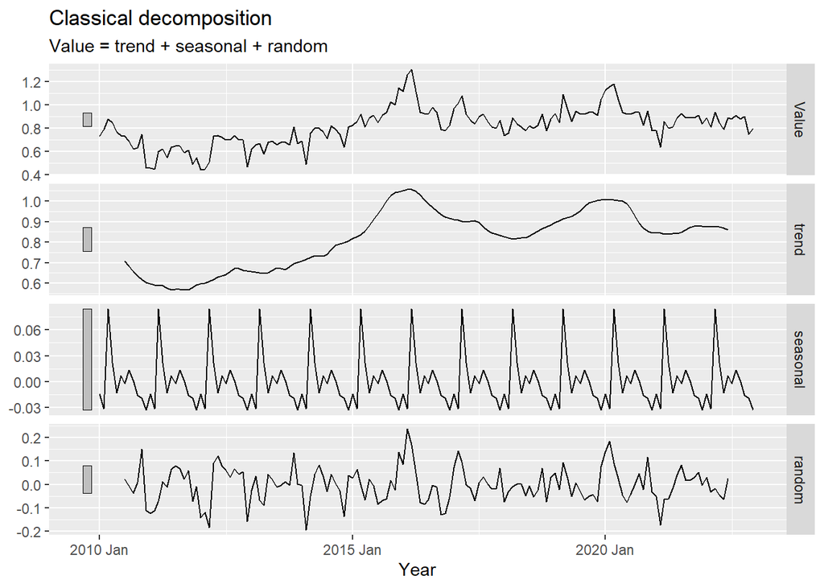

```r
data_monthly %>%
    mutate(Year = yearmonth(Year)) %>%
    as_tsibble(index = Year) %>%
    model(classical_decomposition(Value)) %>%
  components() %>%
  autoplot()
```

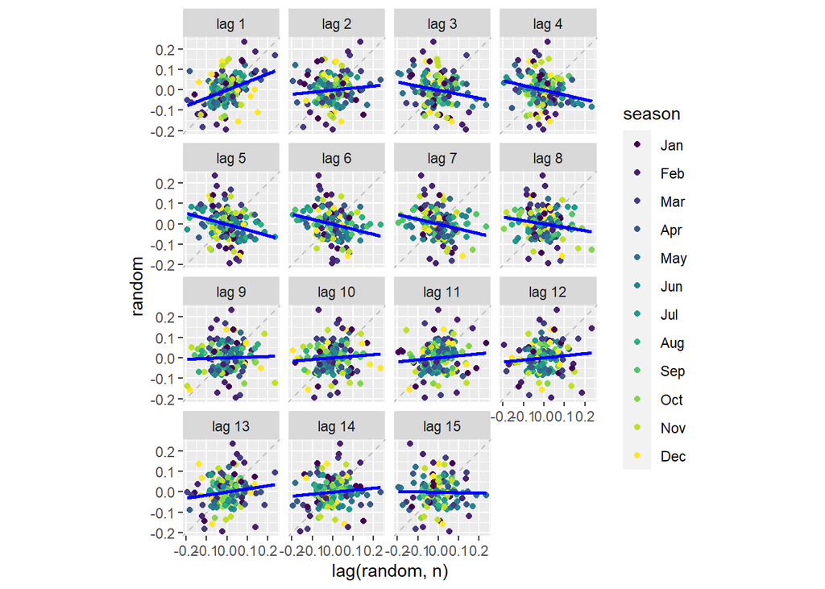

```r
data_monthly %>%
   mutate(Year = yearmonth(Year)) %>%
  as_tsibble(index=Year) %>%
  model(
    classical_decomposition(Value,'additive')
  ) %>%
  components() %>%
  gg_lag(random, geom = "point", lags = 1:15)+
  geom_smooth(aes(color=NULL),method='lm',color='blue',se=F)
```

### **Checking for Stationarity**

Global temperature anomalies data is prone to a lot of fluctuations due to a multitude of factors. Pollution levels, green house gases, the pandemic in between could have had a significant impact on our data thereby there being a need to check for stationarity/non stationarity.To confirm non stationarity, plotting rolling averages and rolling standard deviations will be our first step in analysis.

*Rolling Average :*

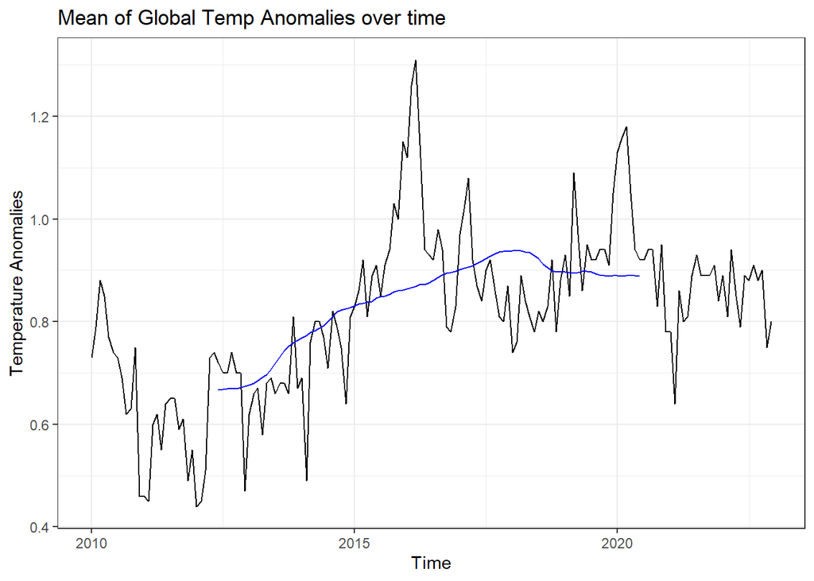

```r
library(zoo)
data_roll <- data_monthly %>%
  mutate(
    close_mean = zoo::rollmean(
      Value,
      k = 60,
      fill = NA),
    close_sd = zoo::rollapply(
      Value,
      FUN = sd,
      width = 60,
      fill = NA)
  )

data_rollmean <- data_roll %>%
  ggplot() +
    geom_line(aes(Year, Value)) +
  geom_line(aes(Year, close_mean),color='blue') +
  theme_bw() +
  ggtitle("Mean of Global Temp Anomalies over time") +
  ylab("Temperature Anomalies") +
  xlab("Time")

data_rollmean
```

The above plot tells us that the mean is not stationary because it is not constant , confirming our assumptions.

*Rolling Standard Deviation :*

From the below plot, it is obvious that our data is variance non stationary.

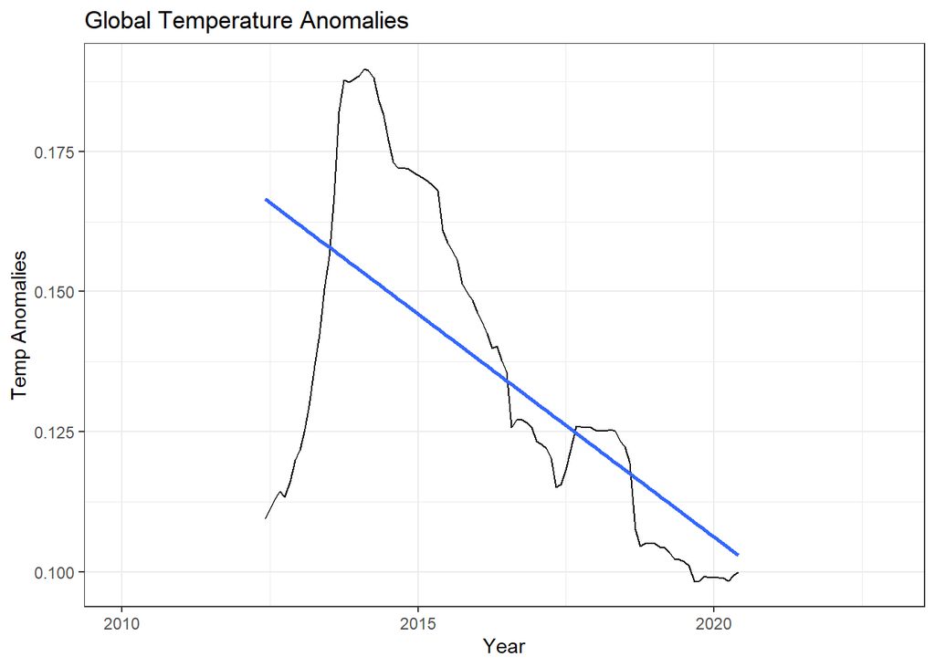

```r
data_rollsd <- data_roll %>%
  ggplot() +
  geom_line(aes(Year, close_sd)) +
  geom_smooth(aes(Year,close_sd),method='lm',se=F)+
  theme_bw() +
  ggtitle("Global Temperature Anomalies") +
  ylab("Temp Anomalies") +
  xlab("Year")

data_rollsd
```

### Transformation:

**Variance Stationary:**

The data at hand is variance non stationary as seen above, therefore it needs to be transformed

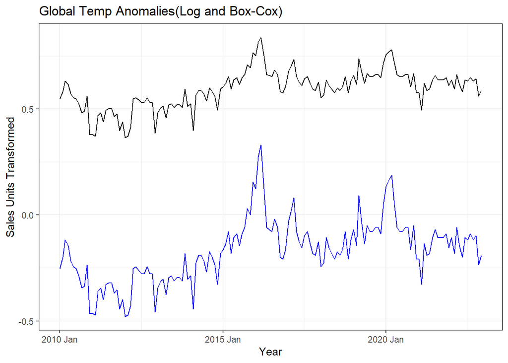

```r
data_monthly <- data_monthly%>%
  mutate(Year = yearmonth(Year))

data_trans <- data_monthly %>%
  mutate(data_log = log1p(Value)) %>%
  mutate(data_boxcox = forecast::BoxCox(Value, lambda = "auto"))

data_trans %>%
  ggplot() +
  geom_line(aes(Year, data_log)) +
  geom_line(aes(Year, data_boxcox),color='blue') +
  theme_bw() +
  ggtitle("Global Temp Anomalies(Log and Box-Cox)") +
  ylab("Sales Units Transformed") +
  xlab("Year")
```

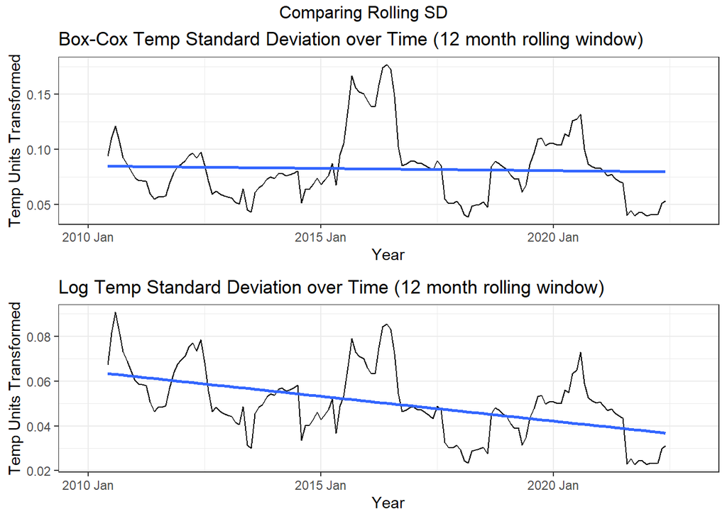

```r
data_roll <- data_trans %>%
  mutate(
    data_log_sd = zoo::rollapply(
      data_log,
      FUN = sd,
      width = 12,
      fill = NA),
    data_box_sd = zoo::rollapply(
      data_boxcox,
      FUN = sd,
      width = 12,
      fill = NA),
  )

log_roll_sd <- data_roll %>%
  ggplot() +
  geom_line(aes(Year, data_log_sd)) +
  geom_smooth(aes(Year,data_log_sd),method='lm',se=F)+
  theme_bw() +
  ggtitle("Log Temp Standard Deviation over Time (12 month rolling window)") +
  ylab("Temp Units Transformed") +
  xlab("Year")

box_roll_sd <- data_roll %>%
  ggplot() +
  geom_line(aes(Year, data_box_sd)) +
  geom_smooth(aes(Year,data_box_sd),method='lm',se=F)+
  theme_bw() +
    ggtitle("Box-Cox Temp Standard Deviation over Time (12 month rolling window)") +
  ylab("Temp Units Transformed") +
  xlab("Year")

grid.arrange(box_roll_sd, log_roll_sd , top = "Comparing Rolling SD" )
```

From the above observations, both box-cox and log transformations are doing good job at making the data variance stationary.

Log transformation reduces variance greatly compared to Box-Cox transformation. So log transformation is preferred over Box-Cox in our case

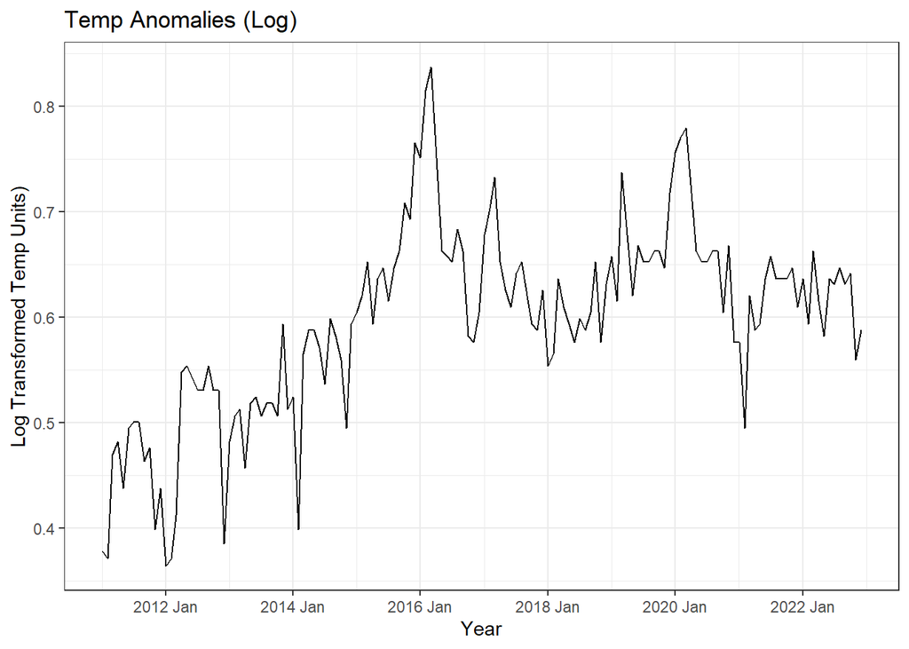

```r
data_diff <- data_monthly %>%
  mutate(
    data_log = log1p(Value),
    data_log_diff = data_log - lag(data_log,12)) %>%
  drop_na() %>%
  as_tsibble(index=Year)




data_diff %>%
  ggplot() +
  geom_line(aes(Year, data_log)) +
  theme_bw() +
  ggtitle("Temp Anomalies (Log)") +
  ylab("Log Transformed Temp Units)") +
  xlab("Year")+
theme_bw()
```

#### *Seasonally Differenced:*

We know that our temperature anomalies dataset has seasonality in it from prior analysis, we are therefore seasonally differencing it.

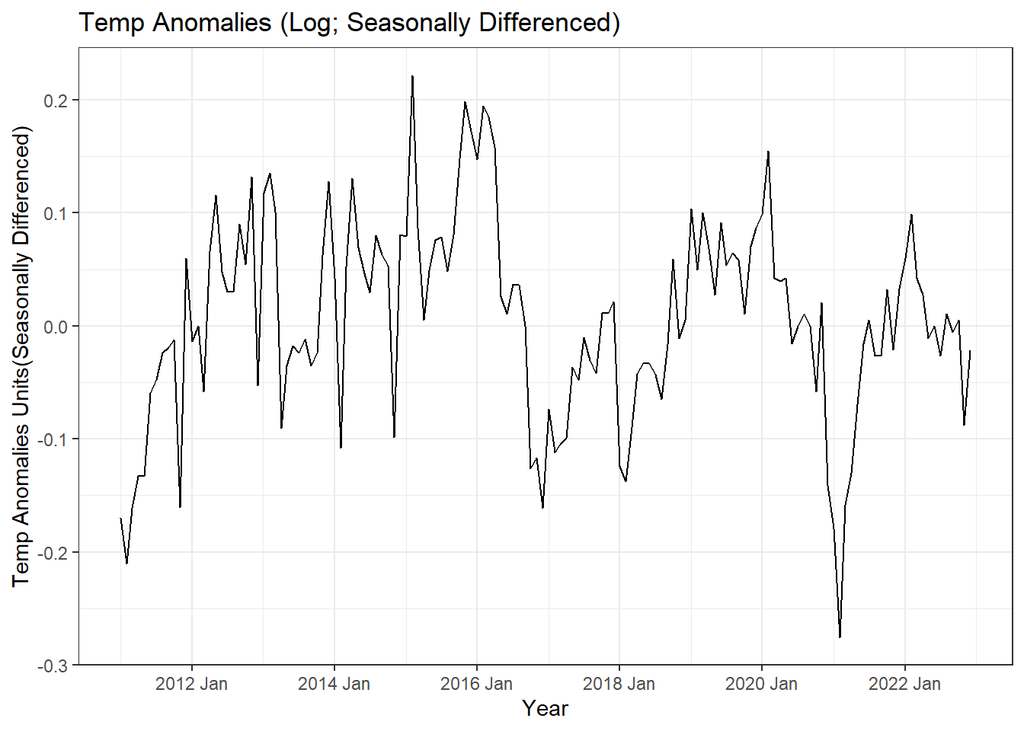

```r
data_diff %>%
  ggplot() +
  geom_line(aes(Year, data_log_diff)) +
  theme_bw() +
  ggtitle("Temp Anomalies (Log; Seasonally Differenced)") +
  ylab("Temp Anomalies Units(Seasonally Differenced)") +
  xlab("Year")+
theme_bw()
```

Above plot gives the Seasonally Differenced, Log Transformed data. Checking our manually derived plot with the tsdisplay function derived seasonally difference plot

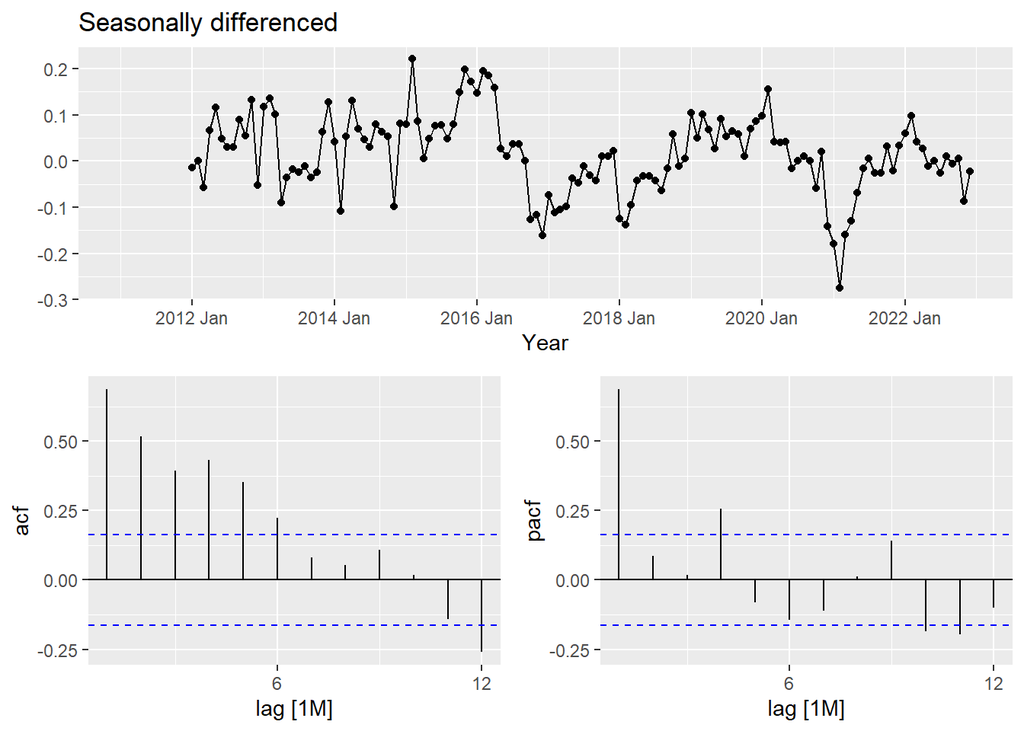

```r
data_diff %>%
  as_tsibble() %>%
# mutate(difference(value,12)) %>%
  gg_tsdisplay(difference(data_log,12),
               plot_type='partial', lag=12) +
  labs(title="Seasonally differenced", y="")
```

### Stationarity Tests:

Performing Augmented Dickey Fuller and KPSS test on the transformed data to check for further presence of non stationarity.

```r
adf.test(data_diff$data_log_diff)
```

```
    Augmented Dickey-Fuller Test

data:  data_diff$data_log_diff
Dickey-Fuller = -3.5509, Lag order = 5, p-value = 0.04028
alternative hypothesis: stationary
```

```r
log_diff_kpss = data_diff %>%
features(data_diff, unitroot_kpss)

log_diff_kpss
```

```
# A tibble: 1 × 2
  kpss_stat kpss_pvalue
      <dbl>       <dbl>
1      2.98        0.01
```

The p value after performing **KPSS test is 0.01 which is less than 0.05**, indicating that the transformed data still is non stationary. So, checking if the data is mean non-stationary

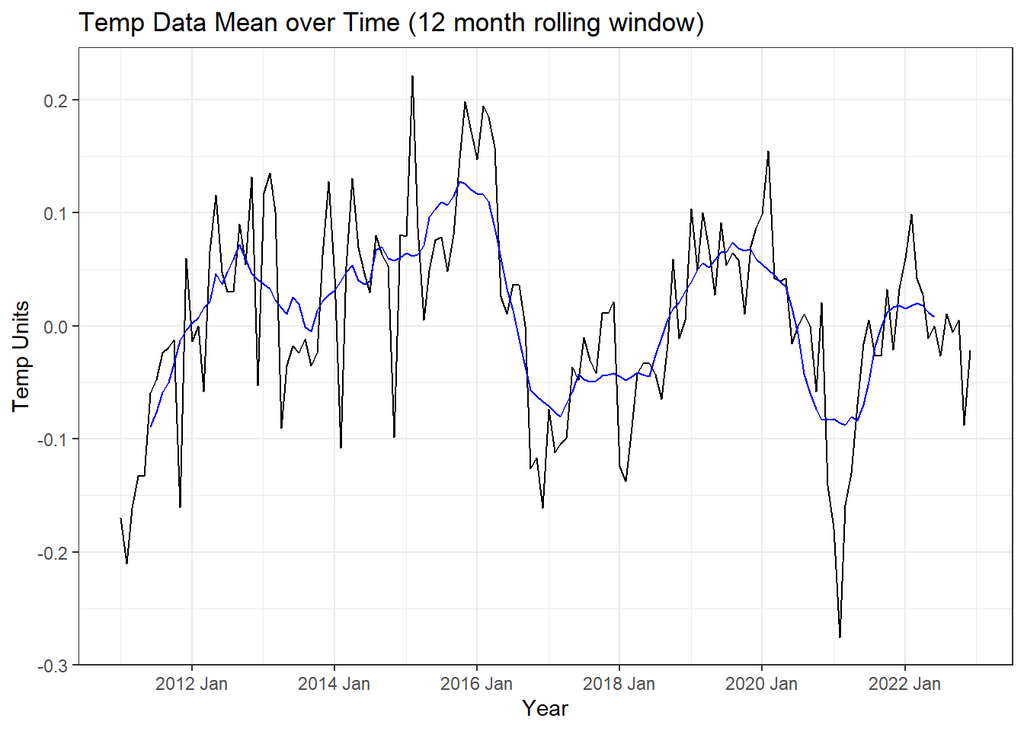

```r
data_roll_trans <- data_diff %>%
  mutate(
    data_mean = zoo::rollmean(
      data_log_diff,
      k = 12,
      fill = NA)
  )

data_roll_trans %>%
  ggplot() +
    geom_line(aes(Year, data_log_diff)) +
  geom_line(aes(Year, data_mean),color='blue') +
  theme_bw() +
  ggtitle("Temp Data Mean over Time (12 month rolling window)") +
  ylab("Temp Units") +
  xlab("Year")
```

This indicates that our data needs to be transformed further.

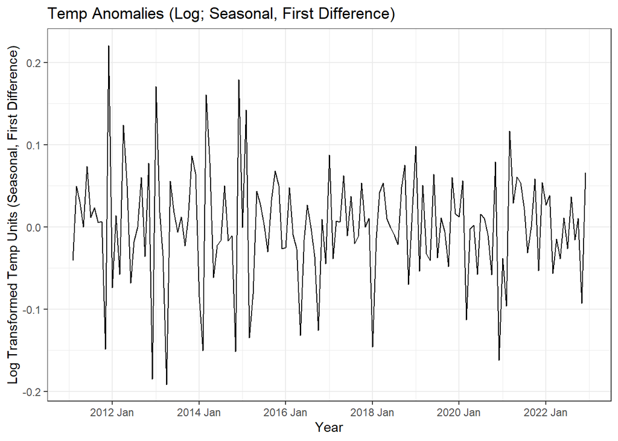

```r
data_diff <- data_diff %>%
  mutate(
    data_log_diff_up = data_log_diff - lag(data_log_diff)) %>%
  drop_na() %>%
  as_tsibble(index=Year)

data_diff %>%
  ggplot() +
  geom_line(aes(Year, data_log_diff_up)) +
  theme_bw() +
  ggtitle("Temp Anomalies (Log; Seasonal, First Difference)") +
  ylab("Log Transformed Temp Units (Seasonal, First Difference)") +
  xlab("Year")+
theme_bw()
```

Performing the KPSS test on the further transformed data to check for remaining non stationarity.

```r
log_diff_kpss_up = data_diff %>%
features(data_log_diff_up, unitroot_kpss)

log_diff_kpss_up
```

```
# A tibble: 1 × 2
  kpss_stat kpss_pvalue
      <dbl>       <dbl>
1    0.0763         0.1
```

*Here the p value is **0.1 which is greater than 0.05**, hence the transformed data is stationary.*

## **Section 2:**

**ACF AND PACF**

*On Original Data :*

For a stationary time series, the ACF will drop to zero relatively quickly, while the ACF of non-stationary data decreases slowly. Also, for non-stationary data, the value of correlation is often large and positive.This can be used to infer that our data is non stationary.

We see a dampening effect in our original ACF plot, which indicates that it could be an Auto regressive or AR process , the PACF plot has two statistically significant lags which indicates that our model could be an AR process of order 2. ARIMA(2,1,0)

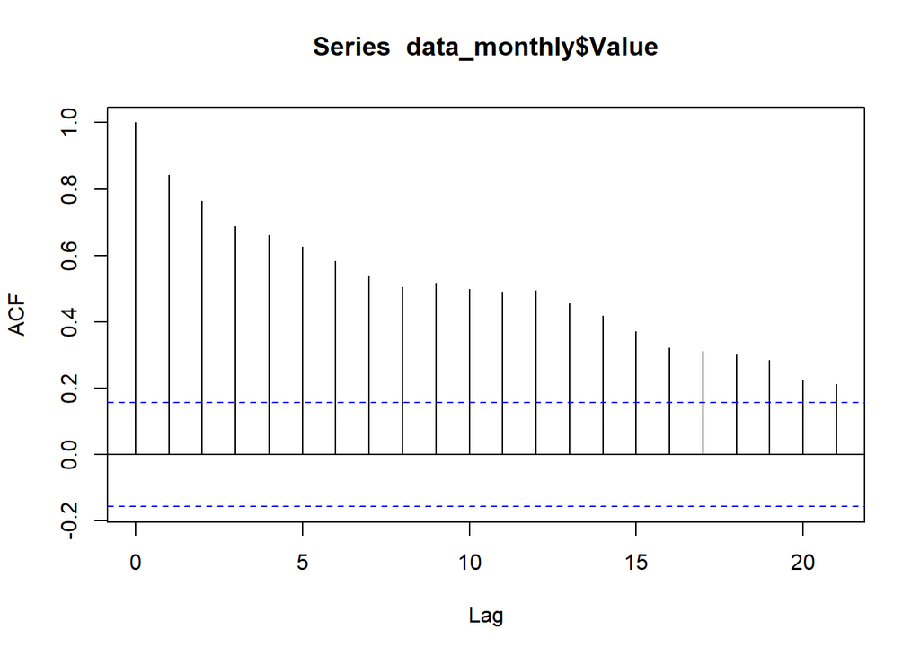

```r
ACF1=acf(data_monthly$Value) %>%
  autoplot()
```

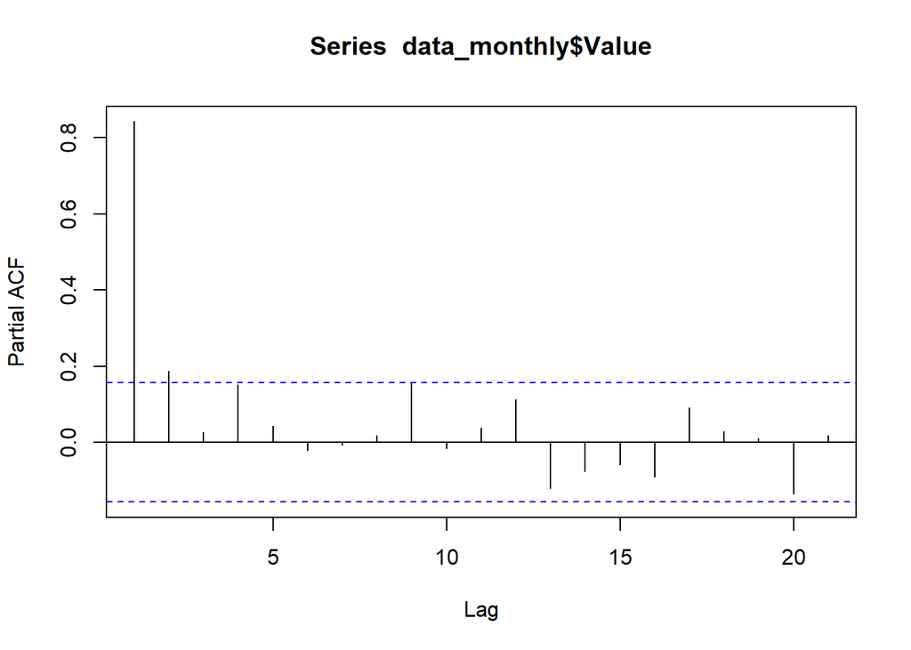

```r
PACF1=pacf(data_monthly$Value) %>%
  autoplot()
```

*On transformed series:*

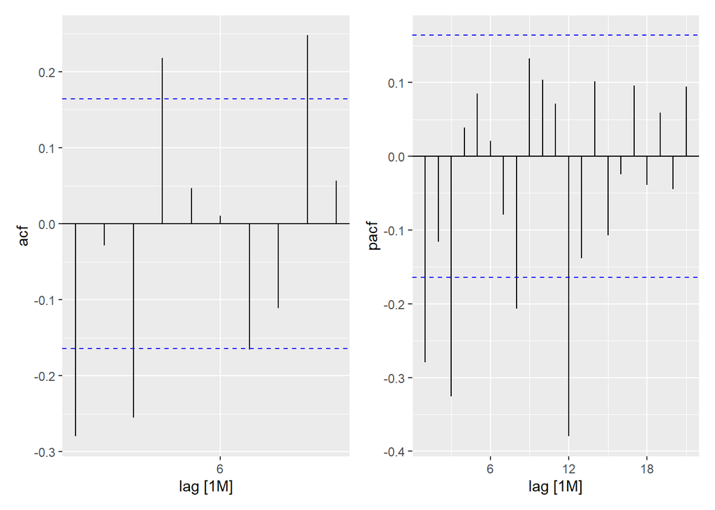

```r
acf = data_diff %>%
  ACF(data_log_diff_up,lag_max=10, na.action = na.pass) %>%
  autoplot()

pacf =  data_diff %>%
  fill_gaps() %>%
  PACF(data_log_diff_up) %>%
  autoplot()

acf + pacf
```

The process for the log transformed data without the differencing can also be checked using ACF/PACF plots as can be seen below.

#### Log Transformed Series

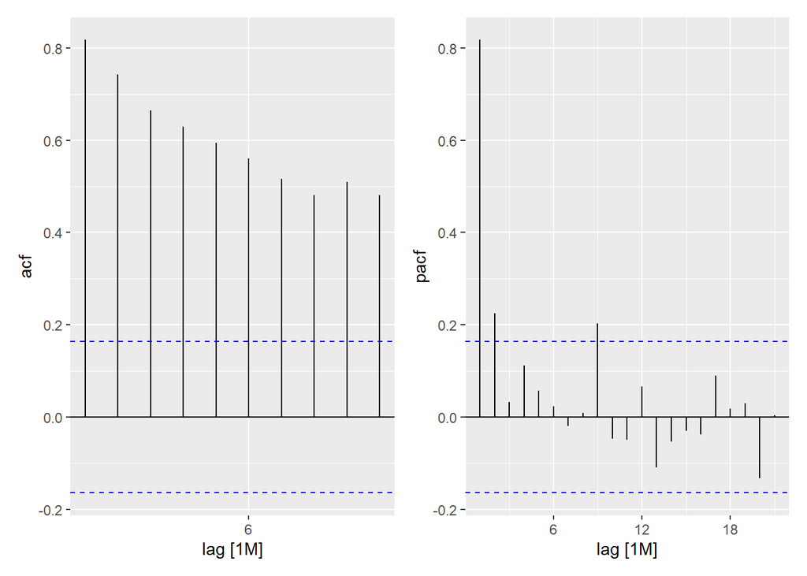

```r
acf_og = data_diff %>%
  as_tsibble()%>%
  ACF(data_log,lag_max=10, na.action = na.pass) %>%
  autoplot()

pacf_og =  data_diff %>%
  as_tsibble()%>%
  fill_gaps() %>%
  PACF(data_log) %>%
  autoplot()

acf_og + pacf_og
```

We also know that the original series is non stationary and has to differenced twice, one for seasonality and one for the first difference. Therefore, the order of Integration is 1. The original data is ARIMA(2,1,0).

The seasonal aspect of ARIMA can be interpretable from ACF/PACF plots as shown below.

#### Seasonal

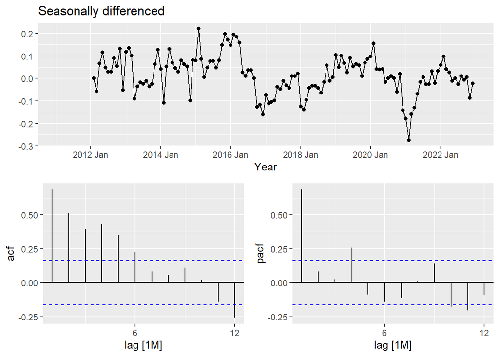

```r
data_diff %>%
  as_tsibble() %>%
  gg_tsdisplay(difference(data_log,12),
               plot_type='partial', lag=12) +
  labs(title="Seasonally differenced", y="")
```

## Section 3

### Model Fitting

Fitting several ARIMA models on the original time series using our best guess from the previous section.

```r
data_monthly <- data_monthly%>%
  mutate(Year = yearmonth(Year))
data_transform <- data_monthly %>%
  mutate(data_log = log1p(Value))
# newdata <- data_diff%>%
#  mutate(data_log_diff=data_log_diff + 1)
# head(newdata)

models_bic = data_transform %>%
  as_tsibble()%>%
  model(
    mod1 = ARIMA(data_log~pdq(0,1,1)+PDQ(1,1,0)),
    mod2 = ARIMA(data_log~pdq(0,1,3)+PDQ(1,1,0)),
    mod3 = ARIMA(data_log~pdq(0,1,3)+PDQ(2,1,0)),
    mod4 = ARIMA(data_log~pdq(3,1,3)+PDQ(0,1,0)),
    mod5 = ARIMA(data_log~pdq(2,1,3)+PDQ(0,1,0))
  )


models_bic %>%
  glance() %>%
  arrange(BIC)
```

```
# A tibble: 5 × 8
  .model  sigma2 log_lik   AIC  AICc   BIC ar_roots   ma_roots
  <chr>    <dbl>   <dbl> <dbl> <dbl> <dbl> <list>     <list>
1 mod3   0.00253    223. -434. -433. -416. <cpl [24]> <cpl [3]>
2 mod1   0.00316    208. -410. -410. -401. <cpl [12]> <cpl [1]>
3 mod2   0.00311    210. -410. -410. -395. <cpl [12]> <cpl [3]>
4 mod4   0.00346    204. -394. -393. -373. <cpl [3]>  <cpl [3]>
5 mod5   0.00378    196. -380. -379. -362. <cpl [2]>  <cpl [3]>
```

### Auto ARIMA

Trying to fit an auto ARIMA model below.

```r
data_transform <- data_monthly %>%
  mutate(data_log = log1p(Value))
data_transform %>%
  as_tsibble()%>%
model(
  ARIMA(data_log,approximation=F, stepwise = F)
) %>%
report()
```

```
Series: data_log
Model: ARIMA(3,1,0)(1,0,1)[12]

Coefficients:
          ar1      ar2      ar3    sar1     sma1
      -0.3013  -0.1261  -0.2348  0.8290  -0.6864
s.e.   0.0800   0.0832   0.0797  0.1854   0.2412

sigma^2 estimated as 0.002258:  log likelihood=254.02
AIC=-496.05   AICc=-495.48   BIC=-477.79
```

```r
best_mod = data_transform %>%
  as_tsibble()%>%
model(
  ARIMA(data_log,approximation=F, stepwise = F)
)
```

**Best Fit Model :** ARIMA(3,10)(1,01)

*Fitted Values:* In-sample predicted values are based on the data used to fit the model, and may reflect the trends in the transformed data but they don’t necessarily capture the underlying trend in the data as a whole. This happens because we use only some part of our data to make predictions and not the entirety of it

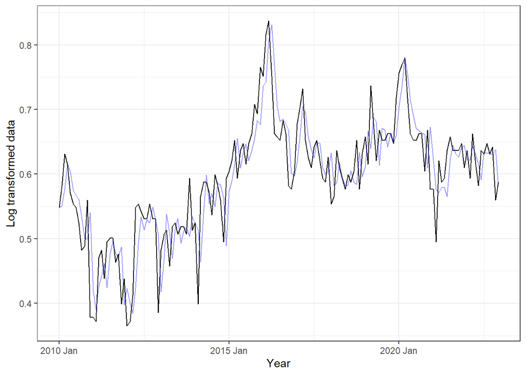

```r
# Get fitted values
fitted = best_mod %>%
  augment() %>%
  .$.fitted

ggplot() +
  geom_line(aes(data_transform$Year, data_transform$data_log)) +
  geom_line(aes(data_transform$Year, fitted), color = "blue", alpha = 0.4) +
  theme_bw() +
  xlab("Year") +
  ylab("Log transformed data")
```

## Section 4

### Residual Diagnostics:

Residual diagnostics help us understand the underlying patterns in our data.We can see that our residuals are normally distributed , so all the patterns in our data are being captured.Our variance seems to follow a constant pattern.

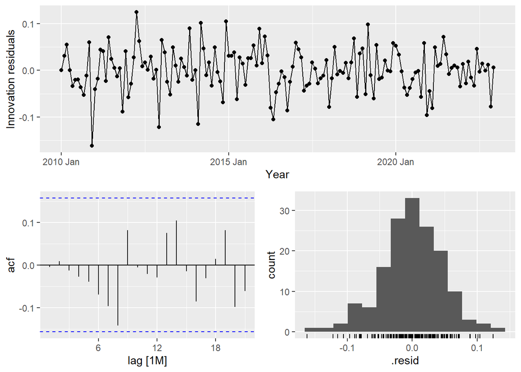

```r
best_mod %>%
  gg_tsresiduals()
```

Above plot shows the residual after fitting the best model to our time series.

To check if the selected model is the best model, further analysis on the residuals has to be done. As part of this, **Ljung-Box test** is performed to find any remaining autocorrelation in the residuals of the best model.

*Ljung-Box test*

```r
best_mod %>%
  augment() %>%
  features(.innov, ljung_box, lag = 7, dof = 6)
```

```
# A tibble: 1 × 3
  .model                                           lb_stat lb_pvalue
  <chr>                                              <dbl>     <dbl>
1 ARIMA(data_log, approximation = F, stepwise = F)    2.77    0.0961
```

The p-value for Ljung-Box test is 0.09 which greater than 0.05 which implies that our residuals have no remaining autocorrelation.

*6 point Forecast:*

The 6 point forecast considers substantial parameters into account therefore it seems to be significant.We have used our best model to predict values, thereby cementing the fact that this is as close as we can get to making a proper forecast. But it does remain that the quality of our 6 point forecast has a lot to do with the quality of our data in picture.

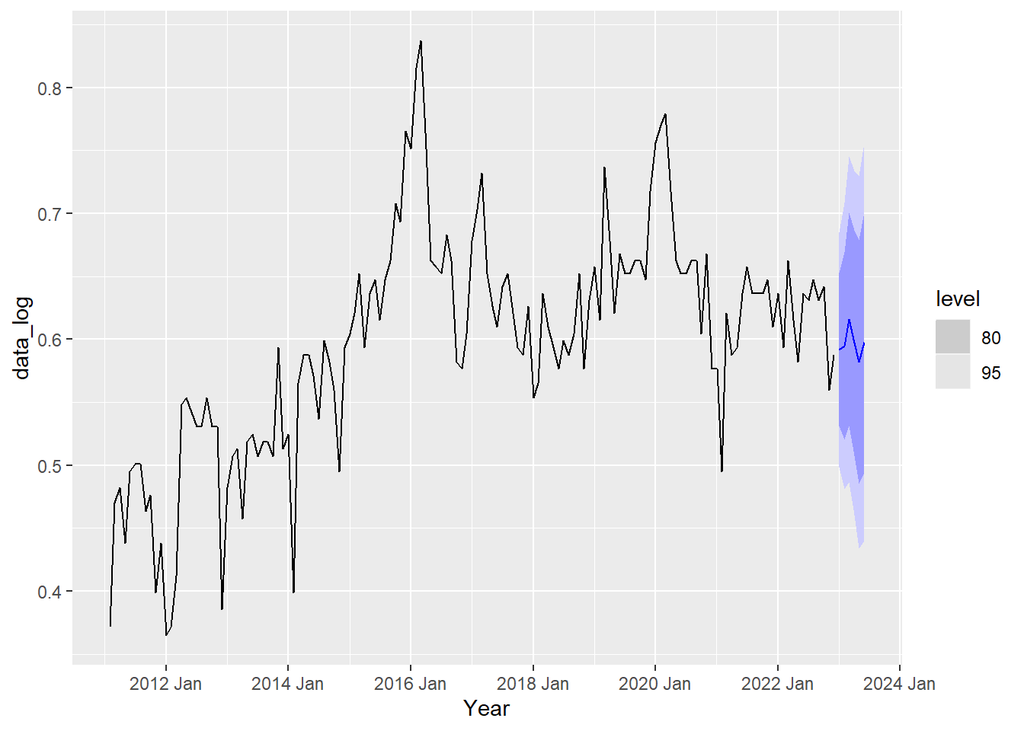

```r
best_mod %>%
  forecast(h=6) %>%
  autoplot(
    data_diff %>%
      select(Year,data_log))
```